# Ayudantía 1

Introducción a Rstudio

Autor/a

Diego Iturrieta

Fecha de publicación

viernes 26 de septiembre, 2025

[figure not shown]

**Estadistica I**  
Ciencias Politicas UAH

# Recordemos…

## ¿Qué es R?

- R es un software diseñado para realizar análisis estadísticos y gráficos. Utiliza un lenguaje de programación de código abierto por lo que cualquier persona puede modificar y compartir sus códigos.
- **R cómo un lenguaje de programación:** Cuando hablamos de un lenguaje, nos referimos a que R nos permite dar instrucciones para que se ejecuten las tareas que queremos realizar.
- **Rstudio:** Para interpretar este lenguaje (las instrucciones) necesitamos un entorno, Rstudio será nuestro entorno de desarrollo integrado que nos permitirá trabajar más cómodamente con R.

## ¿Por qué utilizar R?

R fue creado específicamente para la estadística, por lo que cuenta con miles de funciones nativas y paquetes que facilitan el análisis descriptivo, inferencial y predictivo. Además contiene una gran cantidad de paquetes que se adaptan a las necesidades de los y las investigadores, de igual forma R es gratuito y de código abierto, lo que permite adaptarlo y usarlo sin restricciones de licencias comerciales, a diferencia de otros softwares estadísticos como SPSS o Stata.

**¿Y si no me gusta R?**

Existen distintas plataformas como JASP, SPSS, etc. pero la mayoria deben ser pagadas y ocupan mucho mas RAM a la hora de trabajar, lo que dificulta su funcionamiento en computadores básicos.

```
Instrucción y ejecución
```

```r
print("Hola")
```

```
[1] "Hola"
```

## Herramientas de RStudio

RStudio integra el lenguaje R facilitando su uso mediante diferentes herramientas.

- **Consola**

[figure not shown]

- **Editor de sintaxis**

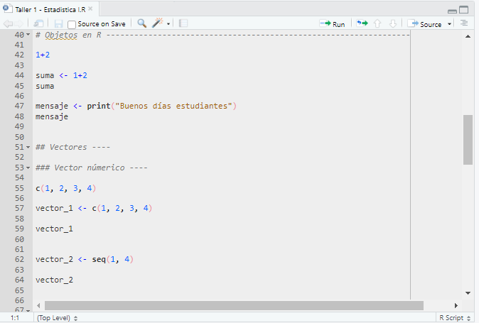

- **Enviroment**

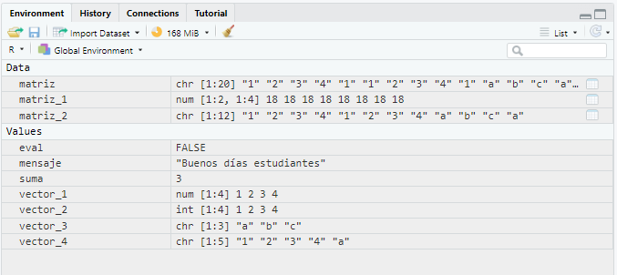

- **Workspace**

[figure not shown]